# Cellulare e i suoi effetti

"L'uomo s'è messo a fabbricar di ferro, d'acciaio le sue nuove divinità ed è diventato servo e schiavo di esse. Viva la Macchina che meccanizza la vita!"

### Motivazione

La scelta è stata condizionata dalla curiosità di comprendere:

- Le abitudini digitali delle persone
- L'impatto sulla salute fisica e mentale.

## Dataset

Ho selezionato diversi dataset da Kaggle oltre ad uno realizzato da me  
Questi trattano:

1. Cellulare con impatto su adolescienti,
2. Comportamenti degli utenti,
3. Cellulare con impatto sulla salute mentale

# Le domande che mi sono posta:

1. Quale fascia d'età passa più tempo al cellulare?
2. Qual è l'impatto delle notifiche su di noi?
3. Quali sono le app più usate dagli utenti? e per quanto tempo vengono usate?
4. C'è correlazione tra l'uso dei social e i livelli di ansia? e con l'autostima?
5. Il telefono prima di dormire influisce sul sonno?

## Tempo allo schermo

La fascia d'età che passa più ore allo schermo è quella di chi ha meno di 15 anni.

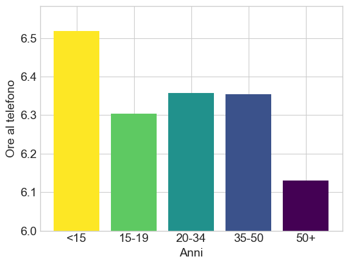

## L'impatto delle notifiche

**Percezione delle notifiche come incentivo all'uso**  
Quasi il 70% delle persone percepiscono le notifiche come distrazione, mentre i restanti sono divisi tra chi non fa uso di notifiche e chi in generale non ne vede il problema.

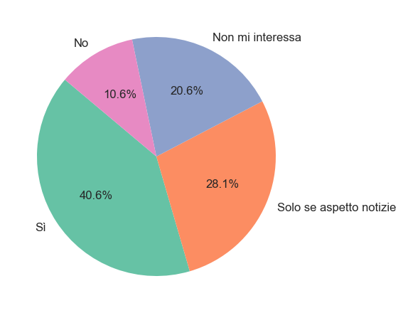

**Realtà - All'aumento delle notifiche aumentano gli sblocchi?**  
Analizza la correlazione tra notifiche ricevute e sblocchi giornalieri, categorizzando gli utenti in base alla loro percezione. La categoria con un maggiore coefficiente di correlazione è "Non mi interessa" con 0.66, seguita dal "Si" con 0.48.

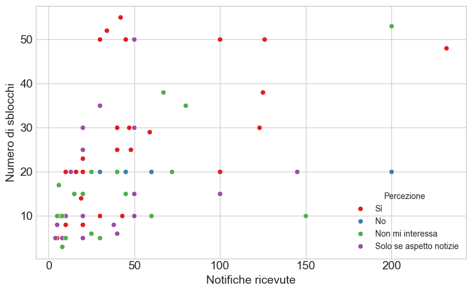

## App più usata in media

Le app che risultano aver per molti un maggior utilizzo sono WhatsApp e Instagram, mentre le minori sono quelle di Intrattenimento e musica.

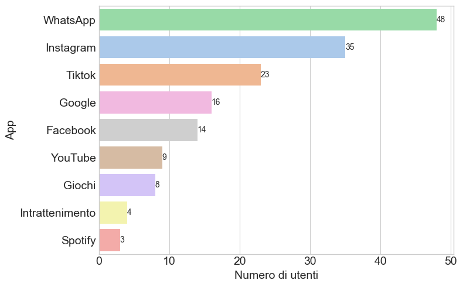

## Tempo medio giornaliero sull’app più usata

Il maggior tempo medio di utilizzi lo ha Tiktok, rendendola l'app più utilizzata.

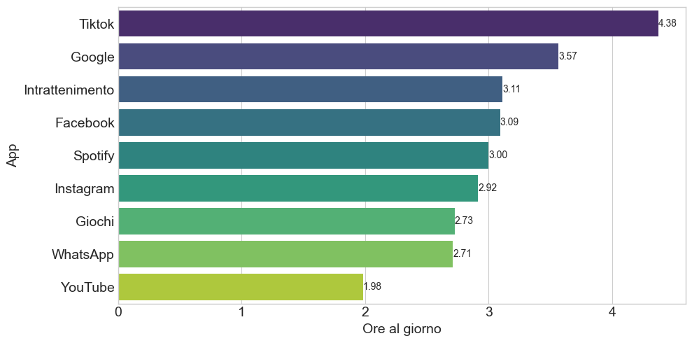

## Relazione Ansia e Ore sui social

L'Heatmap contiene in ogni cella il numero di persone corrispondente alle sue coordinate.  
Considerando il maggiore in ogni colonna si nota un picco alle 2 ore con livello di ansia a 9.

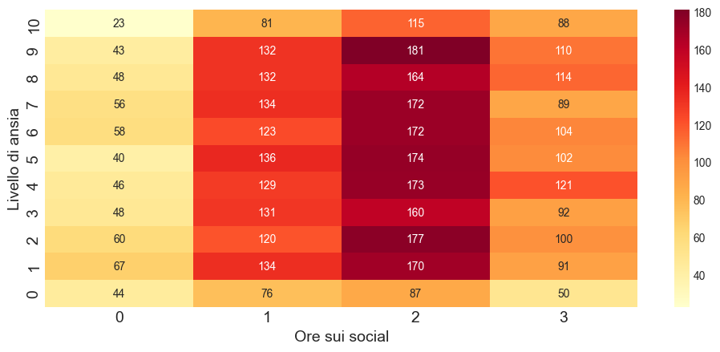

## Relazione tra uso social e autostima

Per i ragazzi, le ore passate sui social influenzano, di poco, l'autostima.  
Al contrario le ragazze non vengono influenzate.

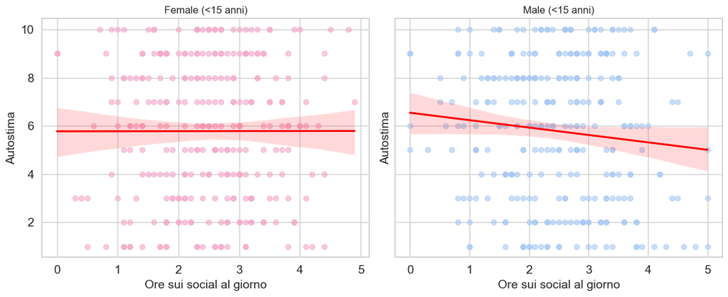

## Ore di schermo vs Sonno

Notiamo stabilità all'inizio, mentre alla fine inizia ad avere dei valori distanti tra loro.  
Nel secondo si nota un leggero calo, con dei picchi maggiori all'inizio e alla fine.

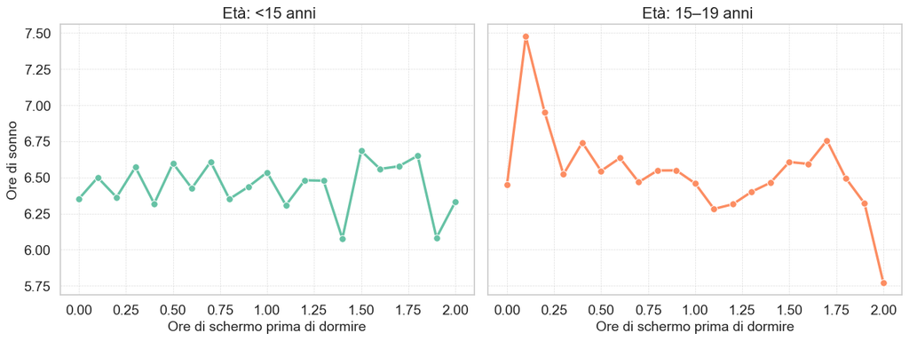

# Conclusioni

L’analisi evidenzia che:

- I più giovani (sotto i 15 anni) sono coloro che trascorrono più tempo allo schermo.
- WhatsApp e Instagram, le app più usate.
- Riguardo il tempo trasacorso su esse Tiktok è quella più usata.
- Il legame tra social e ansia non emerge chiaramente.
- Nei ragazzi i social sembrano avere una leggera influenza sull'autostima.